# Early prediction of student`s outcome in higher education based on demographic, macroeconomic and socioeconomic factors

Miras Kanatzhanov, 13075012

Supervisor: Dr. Reza Mohammadi

2023-11-01

```r
library( ggplot2 )
library( plyr )
library( liver )
library( forcats )
library( Hmisc )
library( naniar )
library( forcats )
library( readr )
library( psych )
library( dplyr )
library( corrplot )
library( GGally )
library( tidyverse )
library( lsr )
library( ggcorrplot )
library( rpart )
library( rpart.plot )
library( pROC )
library( C50 )
library( randomForest )
library( caret )
library( broom )
library( car )
```

```r
# During transportation of the `dropout` dataset we select every variable's type separately
# We do it because the raw data is provided in csv format which does not indicate the right variable types
dropout <- read_delim("C:/Users/miras/Desktop/R Default Directory/Project/data_drop.csv", delim = ";", escape_double = TRUE, trim_ws = TRUE, show_col_types = TRUE, col_types = cols(
     `Marital status` = col_factor(),
     `Application mode` = col_factor(),
     `Application order` = col_factor(),
     Course = col_factor(),
     `Daytime/evening attendance` = col_factor(),
     `Previous qualification` = col_factor(),
     `Previous qualification (grade)` = col_double(),
     Nacionality = col_factor(),
     `Mother's qualification` = col_factor(),
     `Father's qualification` = col_factor(),
     `Mother's occupation` = col_factor(),
     `Father's occupation` = col_factor(),
     `Admission grade` = col_double(),
     Displaced = col_factor(),
     `Educational special needs` = col_factor(),
     Debtor = col_factor(),
     `Tuition fees up to date` = col_factor(),
     Gender = col_factor(),
     `Scholarship holder` = col_factor(),
     `Age at enrollment` = col_integer(),
     International = col_factor(),
     `Curricular units 1st sem (credited)` = col_double(),
     `Curricular units 1st sem (enrolled)` = col_double(),
     `Curricular units 1st sem (evaluations)` = col_double(),
     `Curricular units 1st sem (approved)` = col_double(),
     `Curricular units 1st sem (grade)` = col_double(),
     `Curricular units 1st sem (without evaluations)` = col_double(),
     `Curricular units 2nd sem (credited)` = col_double(),
     `Curricular units 2nd sem (enrolled)` = col_double(),
     `Curricular units 2nd sem (evaluations)` = col_double(),
     `Curricular units 2nd sem (approved)` = col_double(),
     `Curricular units 2nd sem (grade)` = col_double(),
     `Curricular units 2nd sem (without evaluations)` = col_double(),
     `Unemployment rate` = col_double(),
     `Inflation rate` = col_double(),
     GDP = col_double(),
     Target = col_factor()
  ) )
```

# 1 Introduction

Academic success in higher education is vital to the job market, social justice, and economic growth. Dropout is the most problematic issue faced by the higher education institutions across the world. In the job market, a higher education degree brings significant financial benefits. Generally speaking, workers in OECD countries who have completed their university education earn twice as much on average as those who have only completed their high school education. Furthermore, a higher level of education lowers the chance of unemployment (Ortiz et al., 2013). Additionally, high dropout rates might harm an institution’s reputation and hinder future recruitment efforts. This is due to the possibility that institutional dropout rates would be seen by prospective students as an indication of inadequate instruction and assistance provided by the institution. From the perspective of society, dropouts are considered to be a waste of tax resources since they prevent another student from obtaining a spot at the institution (Voelkle & Sander, 2008 in Sosu and Pheunpha, 2019). Therefore, the cause of dropout within university students is a highly researched topic. The research on dropout rates is usually country or region-specific, because that way it becomes easier for policy-makers to capture important trends and come up with suitable solutions (Ortiz et al., 2013; Beaulac, 2019; Migueis et al., 2018). Our research is based on a data set, compiled from the responses of students from a Polytechnic Institute of Portalegre, Portugal. We aim to add on to the existing research and extend the international data pool on the causes of dropout rates and contribute to the capturing of global tendencies.

There is no generally accepted definition of dropping out. Depending on how screening is determined, data source and calculation methods, the proportion of students who drop out varies from study to study. Often in the research literature, dropout is analyzed based on dropout time (sooner or later) (Dobson & Henderson, 2003; Migueis et al., 2018). Due to differences in reporting, it is not possible to compare dropouts rates by institutions. In this work, we define dropouts from a micro perspective, where changes in the field of activity and institution are considered dropouts regardless of time it happens.

Our data set is comprised of variables that determine the student’s family history with higher education institutions and the social class background of the student, student’s personal characteristic as well as factors that determine the state of the economy at the time when a specific response was collected. The data set was already pre-processed and data anomalies as well as class imbalances were handled (Martins et al., 2021). In our analysis, we will first determine variables that will be useful for determining whether a person will stay enrolled or will dropout using hypothesis testing. Afterwards, we will combine these variables into 4 classification models: CART, C5.0, logistic regression and random forest and determine which model has the highest prediction power.

# 2 Business Understanding Stage

Early prediction of student outcomes has attracted increasing research interest.

The dataset includes information known at the time of student enrollment (academic path, demographics, and macroeconomics and socioeconomic factors) and the students’ academic performance at the end of the first and second semesters.

Universities are interested to know:

- **What** are the causes or reasons of dropouts?
- **Why** are we losing students?
- **How** do we stop them from leaving the university?

To answer these questions here, we use the *dropout* data set that is available here: https://archive.ics.uci.edu/dataset/697/predict+students+dropout+and+academic+success

# 3 Data Understanding Stage

This dataset is supported by program SATDAP - Capacitacao da Administracao Publica under grant POCI-05-5762-FSE-000191, Portugal.

The data set initially contains 4424 rows (student records) and 37 columns (features). The `Target` column is the target variable which indicates whether the student dropped out, enrolled in a different university, or graduated. The original 37 variables include:

> 1. `Application order`: The order in which the student applied - ‘Is the university a first choice of the student, second or etc?’ (Categorical-Ordinal)
> 2. `Daytime/evening attendance`: Whether the student attends classes during the day or in the evening. (Categorical-Binary)
> 3. `Previous qualification`: Previous qualification of the student. (Categorical-Nominal)
> 4. `Previous qualification (grade)`: Grade of previous qualification, between 0 and 200. (Numerical-Continuous)
> 5. `Admission grade`: Admission grade, between 0 and 200. (Numerical-Continuous)
> 6. `Displaced`: Whether the student is displaced from their initial home. (Categorical-Binary)
> 7. `Educational special needs`: Whether the student has any special educational needs. (Categorical-Binary)
> 8. `Debtor`: Whether the student is a debtor. (Categorical-Binary)
> 9. `Tuition fees up to date`: Whether the student’s tuition fees are up to date. (Categorical-Binary)
> 10. `Gender`: The gender of the student. (Categorical-Binary)
> 11. `Scholarship holder`: Whether the student is a scholarship holder. (Categorical-Binary)
> 12. `Age at enrollment`: The age of the student at the time of enrollment. (Numerical-Count)
> 13. `International`: Whether the student has an international passport. (Categorical-Binary)
> 14. `Unemployment rate`: Unemployment rate in %. (Numerical-Continuous)
> 15. `Inflation rate`: Inflation rate in %. (Numerical-Continuous)
> 16. `GDP`: change in GDP in %. (Numerical-Continuous)

Some variables will be changed in the following `Data Preprocessing` phase in order to rationalize the *dropout* dataset. We would transform the variable `Target` because we want our target factor to be binary in order to perform learning techniques like Binary Logistic Regression.

> 17. `Marital status`: The marital status of the student. Is he/she single, married or etc. (Categorical-Nominal)
> 18. `Course`: The major taken by the student. (Categorical-Nominal)
> 19. `Mother's qualification`: The qualification of the student’s mother. (Categorical-Nominal)
> 20. `Father's qualification`: The qualification of the student’s father. (Categorical-Nominal)
> 21. `Mother's occupation`: The occupation of the student’s mother. (Categorical-Nominal)
> 22. `Father's occupation`: The occupation of the student’s father. (Categorical-Nominal)
> 23. `Target`: Target variable. `graduate` means that the student obtained the degree in time. `enrolled` means that the student took until three extra years to obtain the degree. `dropout` means that the student took more than three extra years to obtain the degree or does not obtain the degree at all. (Categorical-Binary)

However, we will not utilize some of the original variables because our research objectives do not use the information about academic progress during the studies. We focus on student factors before the admission to the university (demographic, social, macroeconomic factors, and admission specifics). Variables that would be dropped out are the records of academic performance of a student during 1st and 2nd semesters:

> 24. `Curricular units 1st sem (credited)`: The number of curricular units credited by the student in the first semester. (Numerical-Continuous)
> 25. `Curricular units 1st sem (enrolled)`: The number of curricular units enrolled by the student in the first semester. (Numerical-Continuous)
> 26. `Curricular units 1st sem (evaluations)`: The number of curricular units evaluated by the student in the first semester. (Numerical-Continuous)
> 27. `Curricular units 1st sem (approved)`: The number of curricular units approved by the student in the first semester. (Numerical-Continuous)
> 28. `Curricular units 1st sem (without evaluations)`: Number of curricular units without evaluations in the 1st semester. (Numerical-Continuous)
> 29. `Curricular units 2nd sem (credited)`: Number of curricular units credited in the 2nd semester. (Numerical-Continuous)
> 30. `Curricular units 2nd sem (credited)`: Number of curricular units credited in the 2nd semester. (Numerical-Continuous)
> 31. `Curricular units 2nd sem (enrolled)`: Number of curricular units enrolled in the 2nd semester. (Numerical-Continuous)
> 32. `Curricular units 2nd sem (evaluations)`: Number of evaluations to curricular units in the 2nd semester. (Numerical-Continuous)
> 33. `Curricular units 2nd sem (approved)`: Number of curricular units approved in the 2nd semester. (Numerical-Continuous)
> 34. `Curricular units 2nd sem (grade)`: Grade average in the 2nd semester (between 0 and 20). (Numerical-Continuous)
> 35. `Curricular units 2nd sem (without evaluations)`: Number of curricular units without evaluations in the 1st semester. (Numerical-Continuous)

Furthermore, we will also eliminate a couple of factors that are informatively represented by other variables. First variable, `Application mode` is interconnected with such factors like `Age at enrollment` and `International`. Second variable, `Nacionality` already linked with `International` factor.

> 36. `Application mode`: The method of application used by the student. (Categorical-Nominal)
> 37. `Nacionality`: The nationality of the student. (Categorical-Nominal)

## 3.1 Data Preprocessing

`Nacionality` and `International` variables hold the same informational value. In the case with `Nacionality`, by unnecessary keeping such a categorical variable with many names of origin countries, the complexity of the model increases, however, `International` variable already represents whether a student has Portuguese residency (Local) or not (International). Our regression analysis formula would be enormously big which in our example is not a good practice.

`Aplication mode` is already informatively connected with factors `Age at enrollment` and `International`. By removing this factor our model decreases in complexity but not in accuracy.

`Curricular units` class of variables are out of scope of our research objective so we drop them.

```r
dropout$`Application mode` <- NULL
dropout$`Nacionality` <- NULL
dropout$`Curricular units 1st sem (credited)` <- NULL
dropout$`Curricular units 1st sem (enrolled)`<- NULL
dropout$`Curricular units 1st sem (evaluations)` <- NULL
dropout$`Curricular units 1st sem (approved)` <- NULL
dropout$`Curricular units 1st sem (grade)` <- NULL
dropout$`Curricular units 1st sem (without evaluations)` <- NULL
dropout$`Curricular units 2nd sem (credited)` <- NULL
dropout$`Curricular units 2nd sem (enrolled)` <- NULL
dropout$`Curricular units 2nd sem (evaluations)` <- NULL
dropout$`Curricular units 2nd sem (approved)` <- NULL
dropout$`Curricular units 2nd sem (grade)` <- NULL
dropout$`Curricular units 2nd sem (without evaluations)` <- NULL
```

Quick view at the `dropout` dataset:

```r
str(dropout)
```

```
## spc_tbl_ [4,424 × 23] (S3: spec_tbl_df/tbl_df/tbl/data.frame)
##  $ Marital status                : Factor w/ 6 levels "1","2","4","3",..: 1 1 1 1 2 2 1 1 1 1 ...
##  $ Application order             : Factor w/ 8 levels "5","1","2","4",..: 1 2 1 3 2 2 2 4 5 2 ...
##  $ Course                        : Factor w/ 17 levels "171","9254","9070",..: 1 2 3 4 5 6 7 2 8 8 ...
##  $ Daytime/evening attendance    : Factor w/ 2 levels "1","0": 1 1 1 1 2 2 1 1 1 1 ...
##  $ Previous qualification        : Factor w/ 17 levels "1","19","42",..: 1 1 1 1 1 2 1 1 1 1 ...
##  $ Previous qualification (grade): num [1:4424] 122 160 122 122 100 ...
##  $ Mother's qualification        : Factor w/ 29 levels "19","1","37",..: 1 2 3 4 3 3 1 3 2 2 ...
##  $ Father's qualification        : Factor w/ 34 levels "12","3","37",..: 1 2 3 3 4 3 4 3 5 6 ...
##  $ Mother's occupation           : Factor w/ 32 levels "5","3","9","7",..: 1 2 3 1 3 3 4 3 3 5 ...
##  $ Father's occupation           : Factor w/ 46 levels "9","3","7","10",..: 1 2 1 2 1 3 4 1 1 3 ...
##  $ Admission grade               : num [1:4424] 127 142 125 120 142 ...
##  $ Displaced                     : Factor w/ 2 levels "1","0": 1 1 1 1 2 2 1 1 2 1 ...
##  $ Educational special needs     : Factor w/ 2 levels "0","1": 1 1 1 1 1 1 1 1 1 1 ...
##  $ Debtor                        : Factor w/ 2 levels "0","1": 1 1 1 1 1 2 1 1 1 2 ...
##  $ Tuition fees up to date       : Factor w/ 2 levels "1","0": 1 2 2 1 1 1 1 2 1 2 ...
##  $ Gender                        : Factor w/ 2 levels "1","0": 1 1 1 2 2 1 2 1 2 2 ...
##  $ Scholarship holder            : Factor w/ 2 levels "0","1": 1 1 1 1 1 1 2 1 2 1 ...
##  $ Age at enrollment             : int [1:4424] 20 19 19 20 45 50 18 22 21 18 ...
##  $ International                 : Factor w/ 2 levels "0","1": 1 1 1 1 1 1 1 1 2 1 ...
##  $ Unemployment rate             : num [1:4424] 10.8 13.9 10.8 9.4 13.9 16.2 15.5 15.5 16.2 8.9 ...
##  $ Inflation rate                : num [1:4424] 1.4 -0.3 1.4 -0.8 -0.3 0.3 2.8 2.8 0.3 1.4 ...
##  $ GDP                           : num [1:4424] 1.74 0.79 1.74 -3.12 0.79 -0.92 -4.06 -4.06 -0.92 3.51 ...
##  $ Target                        : Factor w/ 3 levels "Dropout","Graduate",..: 1 2 1 2 2 2 2 1 2 1 ...
##  - attr(*, "spec")=
##   .. cols(
##   ..   `Marital status` = col_factor(levels = NULL, ordered = FALSE, include_na = FALSE),
##   ..   `Application mode` = col_factor(levels = NULL, ordered = FALSE, include_na = FALSE),
##   ..   `Application order` = col_factor(levels = NULL, ordered = FALSE, include_na = FALSE),
##   ..   Course = col_factor(levels = NULL, ordered = FALSE, include_na = FALSE),
##   ..   `Daytime/evening attendance` = col_factor(levels = NULL, ordered = FALSE, include_na = FALSE),
##   ..   `Previous qualification` = col_factor(levels = NULL, ordered = FALSE, include_na = FALSE),
##   ..   `Previous qualification (grade)` = col_double(),
##   ..   Nacionality = col_factor(levels = NULL, ordered = FALSE, include_na = FALSE),
##   ..   `Mother's qualification` = col_factor(levels = NULL, ordered = FALSE, include_na = FALSE),
##   ..   `Father's qualification` = col_factor(levels = NULL, ordered = FALSE, include_na = FALSE),
##   ..   `Mother's occupation` = col_factor(levels = NULL, ordered = FALSE, include_na = FALSE),
##   ..   `Father's occupation` = col_factor(levels = NULL, ordered = FALSE, include_na = FALSE),
##   ..   `Admission grade` = col_double(),
##   ..   Displaced = col_factor(levels = NULL, ordered = FALSE, include_na = FALSE),
```

[output cut: 10 more lines]

```
##   ..   `Curricular units 1st sem (approved)` = col_double(),
##   ..   `Curricular units 1st sem (grade)` = col_double(),
##   ..   `Curricular units 1st sem (without evaluations)` = col_double(),
##   ..   `Curricular units 2nd sem (credited)` = col_double(),
##   ..   `Curricular units 2nd sem (enrolled)` = col_double(),
##   ..   `Curricular units 2nd sem (evaluations)` = col_double(),
##   ..   `Curricular units 2nd sem (approved)` = col_double(),
##   ..   `Curricular units 2nd sem (grade)` = col_double(),
##   ..   `Curricular units 2nd sem (without evaluations)` = col_double(),
##   ..   `Unemployment rate` = col_double(),
##   ..   `Inflation rate` = col_double(),
##   ..   GDP = col_double(),
##   ..   Target = col_factor(levels = NULL, ordered = FALSE, include_na = FALSE)
##   .. )
##  - attr(*, "problems")=<externalptr>
```

That is how our database looks after we deleted factors that are out of scope of our research question and before the transformation of variables. We have 23 variables: 6 numeric factors, 16 categorical factors and 1 target. Earlier, the non-informative factors and variables containing data out of our research scope were eliminated. Now, we are left with 22 predictors that we want to analyze. However, before the `Explanotary Data Analysis` we need to transform some factors for the better understanding and for the preparation for analysis.

## 3.2 Data Transformation

The untouched `dropout` database has encrypted values for categorical data. For more information about each value refer to the website: https://archive.ics.uci.edu/dataset/697/predict+students+dropout+and+academic+success. Because of the sheer numbers of categorical values it would be more efficient to put them in a fewer meaningful categories.

First, inside the `dropout` dataframe we change the variable `Marital Status` into more easy to understand categories:

```r
grouping_ms <- list(
  "Single" = c("1"),
  "Married" = c("2"),
  "Widowed" = c("3"),
  "Divorced" = c("4"),
  "Facto.Union" = c("5"),
  "Legally.Separated" = c("6") )
dropout$`Marital status` <- fct_collapse(dropout$`Marital status`, !!!grouping_ms)
```

Then transform the variable `Course`:

```r
grouping_c <- list(
  "Animation and Multimedia Design" = c("171"),
  "Tourism" = c("9254"),
  "Communication Design" = c("9070"),
  "Journalism and Communication" = c("9773"),
  "Management" = c("9991","9147"),
  "Nursing" = c("9500"),
  "Social Service" = c("9238","8014"),
  "Advertising and Marketing Management" = c("9670"),
  "Basic Education" = c("9853"),
  "Veterinary Nursing " = c("9085"),
  "Equinculture" = c("9130"),
  "Oral Hygiene" = c("9556"),
  "Agronomy" = c("9003"),
  "Biofuel Production Technologies" = c("33"),
  "Informatics Engineering" = c("9119") )
dropout$Course <- fct_collapse(dropout$Course, !!!grouping_c)
```

We prepare and transform the `Mother's qualification` and `Father's qualification` columns to more understandable and readable groups.

```r
grouping_q <- list(
  "Secondary" = c("1","7","8","10","11", "12", "15", "17"),
  "Secondary(<10years)" = c("9","18", "20", "21", "14", "19", "38"),
  "Basic" = c("27", "28", "37" ),
  "Higher(bachelor's)" = c("2","3","6", "30","40", "41", "42"),
  "Higher(>=master's)" = c("4", "5", "33", "34", "31", "43", "44"),
  "Vocational/Technical" = c("32", "13", "16", "29","22", "23", "39", "41"),
  "Unknown/Incomplete" = c("24", "25", "26", "35", "36") )
dropout$`Mother's qualification` <- fct_collapse(dropout$`Mother's qualification`, !!!grouping_q)
dropout$`Father's qualification` <- fct_collapse(dropout$`Father's qualification`, !!!grouping_q)
```

Similarly, we transform categories for `Mother's occupation` and `Father's occupation`:

```r
grouping_m <- list(
  "Student" = c("0"),
  "Public.Administration" = c("1"),
  "Healthcare" = c("122", "132"),
  "Science.Specialist" = c("2", "125"),
  "Science.Intermediate" = c("131", "134", "3"),
  "Armed.Forces" = c("10"),
  "Teacher" = c("123"),
  "Administrative.Support" = c("4", "141", "143", "144"),
  "Service" = c("5", "151", "152", "153"),
  "Skilled.Professions" = c("6", "7", "171", "173", "175"),
  "Manufacturing" = c("8"),
  "Unskilled.Professions" = c("9", "192", "193", "194", "191"),
  "Other.or.Blank" = c("90", "99"))

grouping_f <- list(
  "Student" = c("0"),
  "Teacher" = c("123"),
  "Public.Administration" = c("1"),
  "Armed.Forces" = c("101", "102", "103", "10"),
  "Management" = c("112", "114"),
  "Science.Specialist" = c("124", "2", "121" ),
  "Intermediate.Technicians" = c("131", "135","134", "3"),
  "Healthcare" = c("122", "132"),
  "Administrative.Support" = c("143", "144", "4", "141"),
  "Service" = c("5", "151", "152", "153", "154"),
  "Skilled.Professions" = c("6", "7", "161", "163", "171", "172", "174", "175"),
  "Manufacturing" = c("8", "181", "182", "183"),
  "Unskilled.Professions" = c("9", "192", "193", "194","195" ),
  "Other.or.Blank"= c("90", "99") )
dropout$`Mother's occupation` <- fct_collapse(dropout$`Mother's occupation`, !!!grouping_m)
dropout$`Father's occupation` <- fct_collapse(dropout$`Father's occupation`, !!!grouping_f)
```

Same for variable `Previous qualification`:

```r
grouping_p <- list(
  "Basic" = c("19", "38", "14", "15" ),
  "Secondary" = c("1", "9", "10", "12"),
  "Higher(bachelor's)" = c("2", "3", "40"),
  "Higher(>=master's)" = c("4", "5", "43"),
  "Specialized" = c("39", "42"),
  "Other.or.Blank" = c("6"))
dropout$`Previous qualification` <- fct_collapse(dropout$`Previous qualification`, !!!grouping_p)
```

Additionally, we want to change binary variables with outcome values being equal to 1/0 into categorical with “Yes”/“No”. This is done for further more understandable work with the dataset. We changed variables `Daytime/evening attendance` (also renamed it), `Displaced`, `Educational special needs`, `Debtor`, `Tuition fees up to date`, `Gender`, `Scholarship holder`, and `International`.

```r
names(dropout)[names(dropout) == "Daytime/evening attendance"] <- "Evening attendance"
dropout$`Evening attendance` <- gsub(0,"Yes",dropout$`Evening attendance`)
dropout$`Evening attendance` <- gsub(1,"No",dropout$`Evening attendance`)
dropout$`Evening attendance` <- as.factor(dropout$`Evening attendance`)

dropout$`Displaced` <- gsub(1,"Yes",dropout$`Displaced`)
dropout$`Displaced` <- gsub(0,"No",dropout$`Displaced`)
dropout$`Displaced` <- as.factor(dropout$`Displaced`)

dropout$`Educational special needs` <- gsub(1,"Yes",dropout$`Educational special needs`)
dropout$`Educational special needs` <- gsub(0,"No",dropout$`Educational special needs`)
dropout$`Educational special needs` <- as.factor(dropout$`Educational special needs`)

dropout$`Debtor` <- gsub(1,"Yes",dropout$`Debtor`)
dropout$`Debtor` <- gsub(0,"No",dropout$`Debtor`)
dropout$`Debtor` <- as.factor(dropout$`Debtor`)

dropout$`Tuition fees up to date` <- gsub(1,"Yes",dropout$`Tuition fees up to date`)
dropout$`Tuition fees up to date` <- gsub(0,"No",dropout$`Tuition fees up to date`)
dropout$`Tuition fees up to date` <- as.factor(dropout$`Tuition fees up to date`)

dropout$`Gender` <- gsub(1,"Male",dropout$`Gender`)
dropout$`Gender` <- gsub(0,"Female",dropout$`Gender`)
dropout$`Gender` <- as.factor(dropout$`Gender`)

dropout$`Scholarship holder` <- gsub(1,"Yes",dropout$`Scholarship holder`)
dropout$`Scholarship holder` <- gsub(0,"No",dropout$`Scholarship holder`)
dropout$`Scholarship holder` <- as.factor(dropout$`Scholarship holder`)

dropout$`International` <- gsub(1,"Yes",dropout$`International`)
dropout$`International` <- gsub(0,"No",dropout$`International`)
dropout$`International` <- as.factor(dropout$`International`)
```

The factor level “Enrolled” represents the people, who changed their course of studies. We decided to combine the levels “Enrolled” and “Graduate” into one category “Stayed.enrolled” which are inside the variable `Target`. It is done because the prediction algorithms we would work with rely on binary target variable. Second factor level is called “Dropout” and is left unchanged.

```r
dropout <- dropout %>% mutate(Target = ifelse(Target %in% c("Enrolled", "Graduate"), "Stayed.enrolled", Target))
dropout <- dropout %>% mutate(Target = ifelse(Target %in% 1, "Dropout", Target))
dropout$Target <- as.factor(dropout$Target)
```

## 3.3 Outliers and Unusual values

The research team that gathered information about the dropout rates across Portugal (Martins et al., 2021) stated that they released the `dropout` dataset cleansed from any outliers or missing values.

However, some mistakes were kept in the `Application order` variable. For some reason, the column includes values of “0” and “9” that both appear only once throughout the set. Zero value does not make sense because a student cannot chose university as their 0th choice. Value “9” supposedly tells that a student chose university as their 9th choice. Although, choice of the 9th university potentially can happen in real life but it is clearly an outlier in our dataset, especially when the previous category is a “6”.

Checking to see the values of the variable `Application order`:

```r
ao_specific_value <- c(0, 1, 2, 3, 4, 5, 6, 9)
ao_value_counts <- table(dropout$`Application order`)
ao_count_of_specific_value <- ao_value_counts[as.character(ao_specific_value)]
print(ao_count_of_specific_value)
```

```
##
##    0    1    2    3    4    5    6    9
##    1 3026  547  309  249  154  137    1
```

Leaving outliers untreated would harm the accuracy of the analysis, however, it would not be right to just delete observations from the dataset. Therefore, to treat the outliers we would join those two observations into their closest neighboring categories. For instance, 0th choice becomes the 1st and 9th becomes the 6th.

```r
grouping_a <- list(
  "1" = c("0", "1" ),
  "2" = c("2"),
  "3" = c("3"),
  "4" = c("4"),
  "5" = c("5"),
  "6" = c("6", "9") )
dropout$`Application order` <- fct_collapse(dropout$`Application order`, !!!grouping_a)
```

Again checking the `Application order` variable:

```r
ao_specific_value <- c(1, 2, 3, 4, 5, 6 )
ao_value_counts <- table(dropout$`Application order`)
ao_count_of_specific_value <- ao_value_counts[as.character(ao_specific_value)]
print(ao_count_of_specific_value)
```

```
##
##    1    2    3    4    5    6
## 3027  547  309  249  154  138
```

As we can see, there is no more outliers/unusual values in `Application order` variable.

Next, we would examine numerical variables in the dataset for unusual values.

Checking the variable `Age at enrollment`:

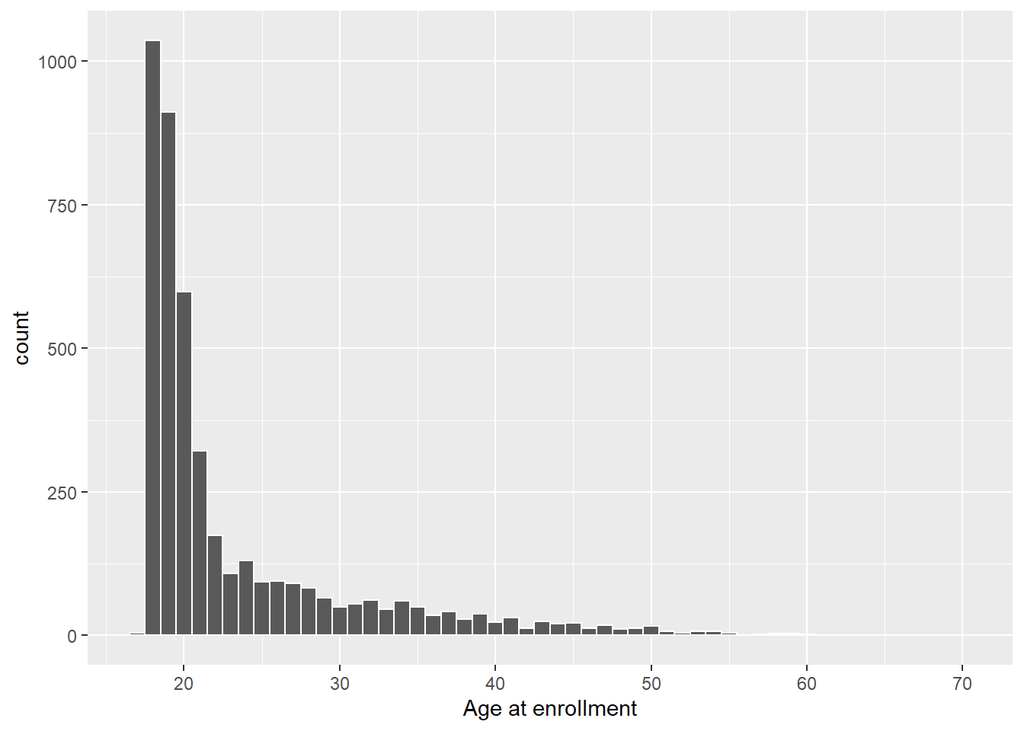

```r
ggplot( data = dropout ) +
    geom_histogram( aes( x = `Age at enrollment` ), binwidth = 1, color = "white")
```

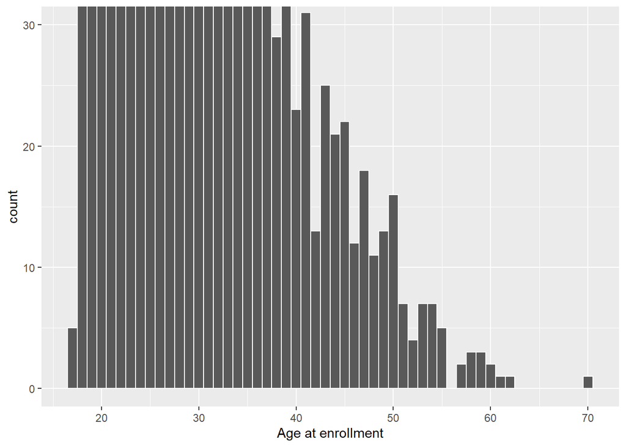

```r
ggplot( data = dropout ) +
    geom_histogram( mapping = aes( x = `Age at enrollment`), binwidth = 1, color = "white" ) +
    coord_cartesian( ylim = c( 0, 30 ) )
```

In the dataset there is one student, whose age is 70 years old, which might look as an outlier. However, we will not manipulate it in any way, it simply means that a person enrolled to the university while being 70 years old.

We check other numerical variables `Unemployment rate`, `Inflation rate` and `GDP`.

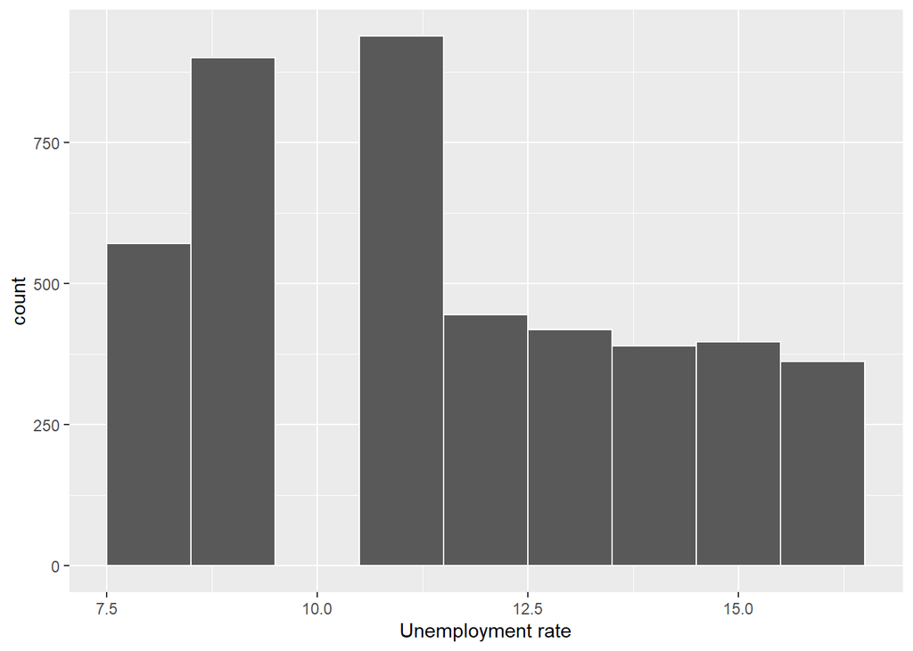

```r
ggplot( data = dropout ) +
    geom_histogram( aes( x = `Unemployment rate`), binwidth = 1, color = "white")
```

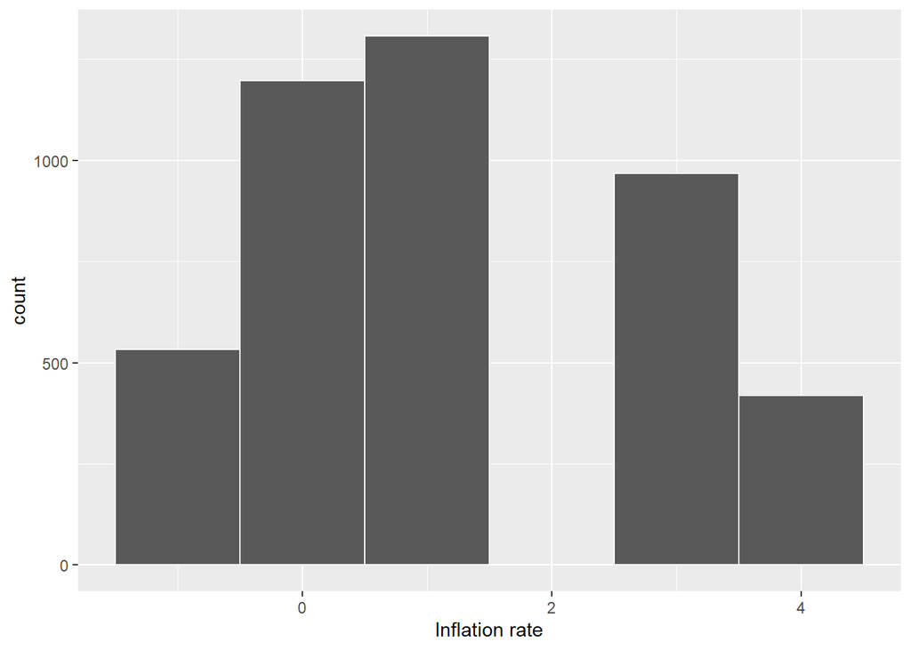

```r
ggplot( data = dropout ) +
    geom_histogram( aes( x = `Inflation rate`), binwidth = 1, color = "white")
```

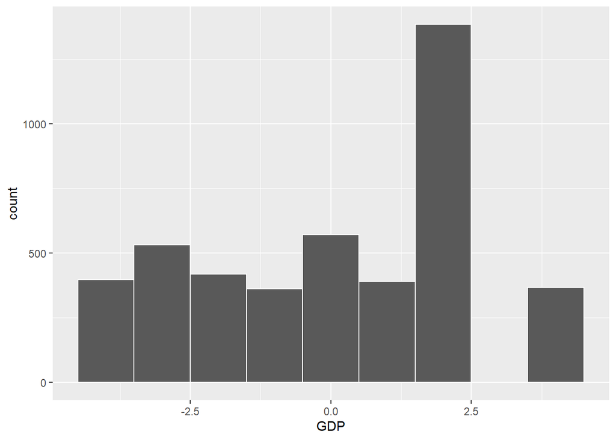

```r
ggplot( data = dropout ) +
    geom_histogram( aes( x = `GDP`), binwidth = 1, color = "white")
```

Variables `Unemployment rate`, `Inflation rate` and `GDP`also have not shown any unusual values.

We also check variables `Previous qualification (grade)` and `Admission grade` for outliers:

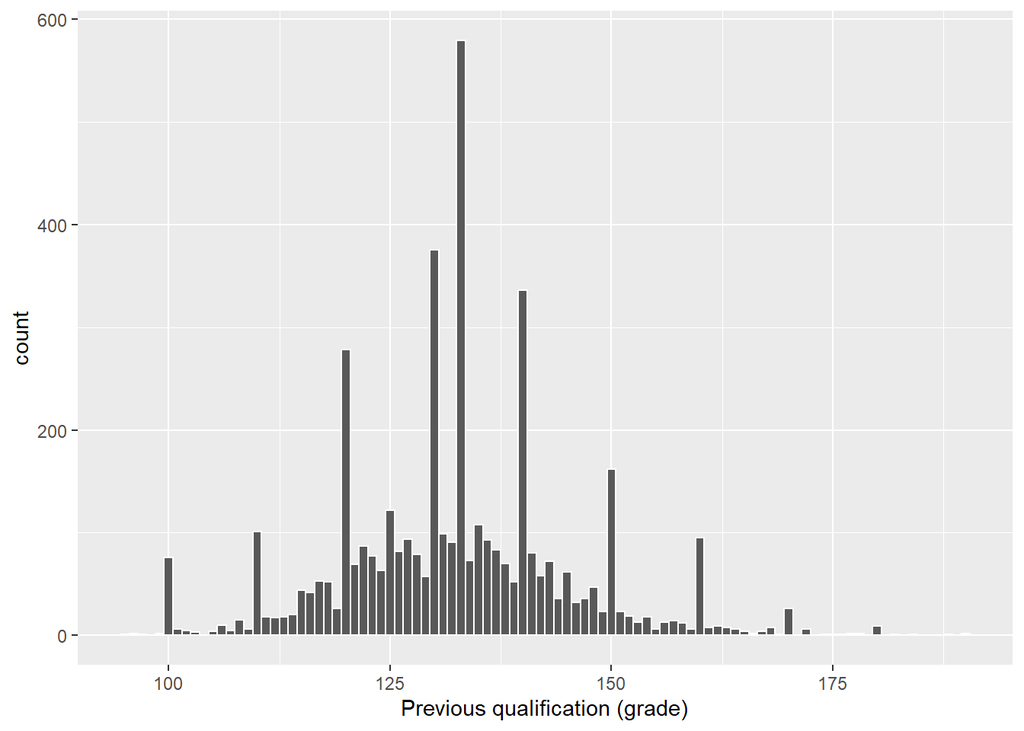

```r
ggplot( data = dropout ) +
      geom_histogram( aes( x = `Previous qualification (grade)`), binwidth = 1, color = "white")
```

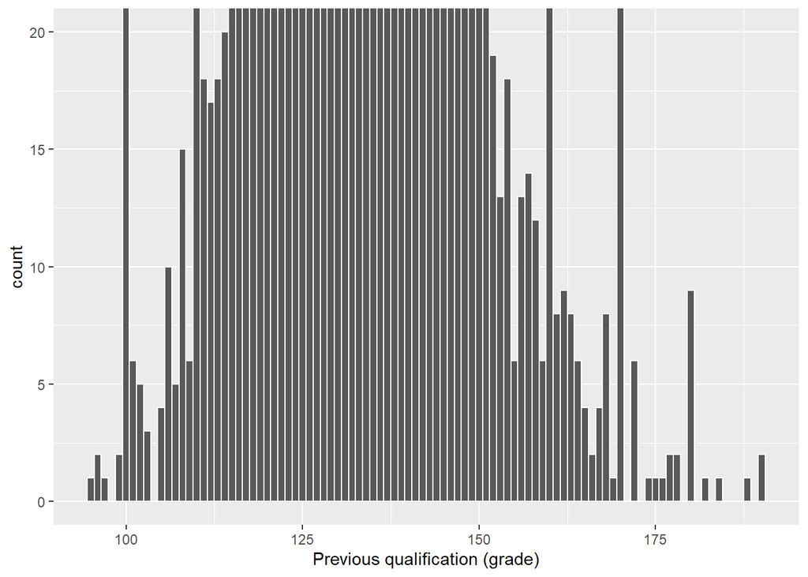

```r
ggplot( data = dropout ) +
      geom_histogram( aes( x = `Previous qualification (grade)`), binwidth = 1, color = "white") +
  coord_cartesian( ylim = c( 0, 20 ) )
```

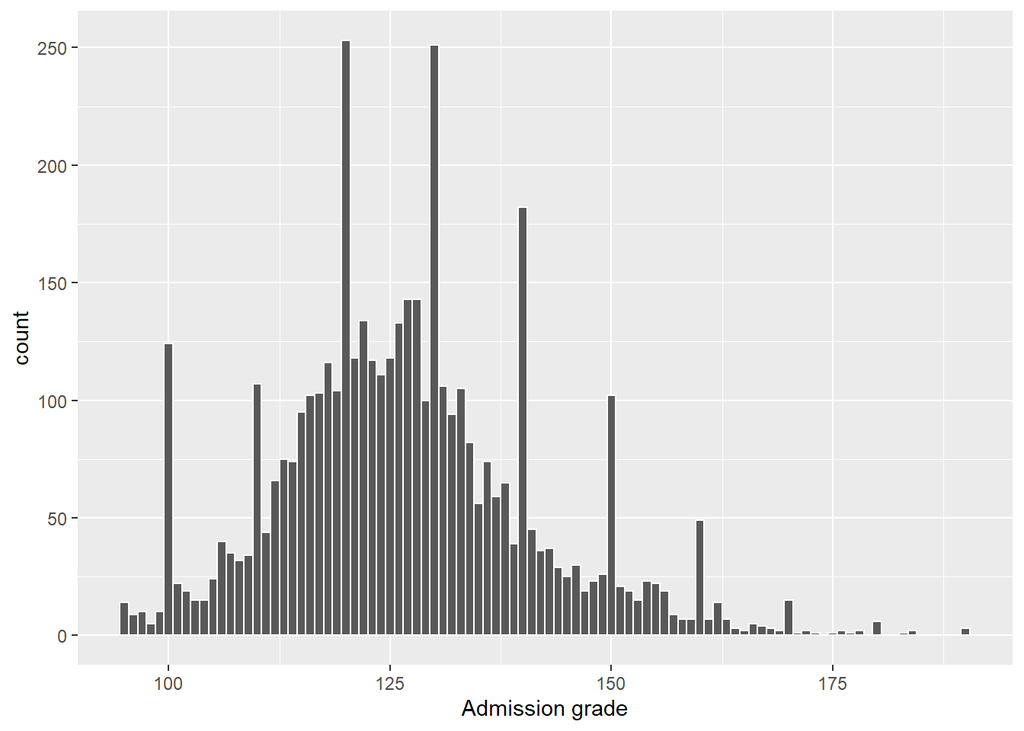

```r
ggplot( data = dropout ) +
      geom_histogram( aes( x = `Admission grade`), binwidth = 1, color = "white")
```

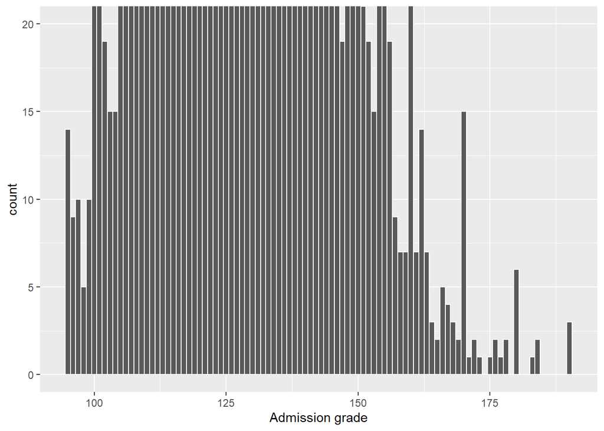

```r
ggplot( data = dropout ) +
      geom_histogram( aes( x = `Admission grade`), binwidth = 1, color = "white") +
  coord_cartesian( ylim = c( 0, 20 ) )
```

Both distribution of `Previous qualification (grade)` and `Admission grade` do not look like normal distributions because the graphs have many unusual spikes that are sticking out from the pattern. Those spikes represent a number of people attaining round grades like 100, 130 or 150. This is a “round number bias” which states that people have psychological tendency to prefer round numbers over others.

For instance, we can compare number of students with round and non-round `Admission grade`:

```r
specific_value <- c(127, 128, 129, 130, 131, 132, 133)
value_counts <- table(dropout$`Admission grade`)
count_of_specific_value <- value_counts[as.character(specific_value)]
print(count_of_specific_value)
```

[output not shown]

And for `Previous qualification (grade)`:

```r
specific_value <- c(127, 128, 129, 130, 131, 132, 133)
value_counts <- table(dropout$`Previous qualification (grade)`)
count_of_specific_value <- value_counts[as.character(specific_value)]
print(count_of_specific_value)
```

```
##
## 127 128 129 130 131 132 133
##  93  79  57 375  99  91  88
```

In both variables, number of students who attained round grade of 130 is several times higher than neighboring non-round grades. Such bias is normal at educational institutions and there is no need to treat the values in `Previous qualification (grade)` and `Admission grade` variables.

After all transformations and treatments

```r
str(dropout)
```

```
## tibble [4,424 × 23] (S3: tbl_df/tbl/data.frame)
##  $ Marital status                : Factor w/ 6 levels "Single","Married",..: 1 1 1 1 2 2 1 1 1 1 ...
##  $ Application order             : Factor w/ 6 levels "5","1","2","4",..: 1 2 1 3 2 2 2 4 5 2 ...
##  $ Course                        : Factor w/ 15 levels "Animation and Multimedia Design",..: 1 2 3 4 5 6 7 2 5 5 ...
##  $ Evening attendance            : Factor w/ 2 levels "No","Yes": 1 1 1 1 2 2 1 1 1 1 ...
##  $ Previous qualification        : Factor w/ 6 levels "Secondary","Basic",..: 1 1 1 1 1 2 1 1 1 1 ...
##  $ Previous qualification (grade): num [1:4424] 122 160 122 122 100 ...
##  $ Mother's qualification        : Factor w/ 7 levels "Secondary(<10years)",..: 1 2 3 1 3 3 1 3 2 2 ...
##  $ Father's qualification        : Factor w/ 7 levels "Secondary","Higher(bachelor's)",..: 1 2 3 3 4 3 4 3 1 4 ...
##  $ Mother's occupation           : Factor w/ 13 levels "Service","Science.Intermediate",..: 1 2 3 1 3 3 4 3 3 5 ...
##  $ Father's occupation           : Factor w/ 14 levels "Unskilled.Professions",..: 1 2 1 2 1 3 4 1 1 3 ...
##  $ Admission grade               : num [1:4424] 127 142 125 120 142 ...
##  $ Displaced                     : Factor w/ 2 levels "No","Yes": 2 2 2 2 1 1 2 2 1 2 ...
##  $ Educational special needs     : Factor w/ 2 levels "No","Yes": 1 1 1 1 1 1 1 1 1 1 ...
##  $ Debtor                        : Factor w/ 2 levels "No","Yes": 1 1 1 1 1 2 1 1 1 2 ...
##  $ Tuition fees up to date       : Factor w/ 2 levels "No","Yes": 2 1 1 2 2 2 2 1 2 1 ...
##  $ Gender                        : Factor w/ 2 levels "Female","Male": 2 2 2 1 1 2 1 2 1 1 ...
##  $ Scholarship holder            : Factor w/ 2 levels "No","Yes": 1 1 1 1 1 1 2 1 2 1 ...
##  $ Age at enrollment             : int [1:4424] 20 19 19 20 45 50 18 22 21 18 ...
##  $ International                 : Factor w/ 2 levels "No","Yes": 1 1 1 1 1 1 1 1 2 1 ...
##  $ Unemployment rate             : num [1:4424] 10.8 13.9 10.8 9.4 13.9 16.2 15.5 15.5 16.2 8.9 ...
##  $ Inflation rate                : num [1:4424] 1.4 -0.3 1.4 -0.8 -0.3 0.3 2.8 2.8 0.3 1.4 ...
##  $ GDP                           : num [1:4424] 1.74 0.79 1.74 -3.12 0.79 -0.92 -4.06 -4.06 -0.92 3.51 ...
##  $ Target                        : Factor w/ 2 levels "Dropout","Stayed.enrolled": 1 2 1 2 2 2 2 1 2 1 ...
```

# 4 Exploratory Data Analysis (EDA)

## 4.1 Investigate the target variable

First, we investigate the target variable `Target`, which shows whether the person has dropped out or stayed enrolled.

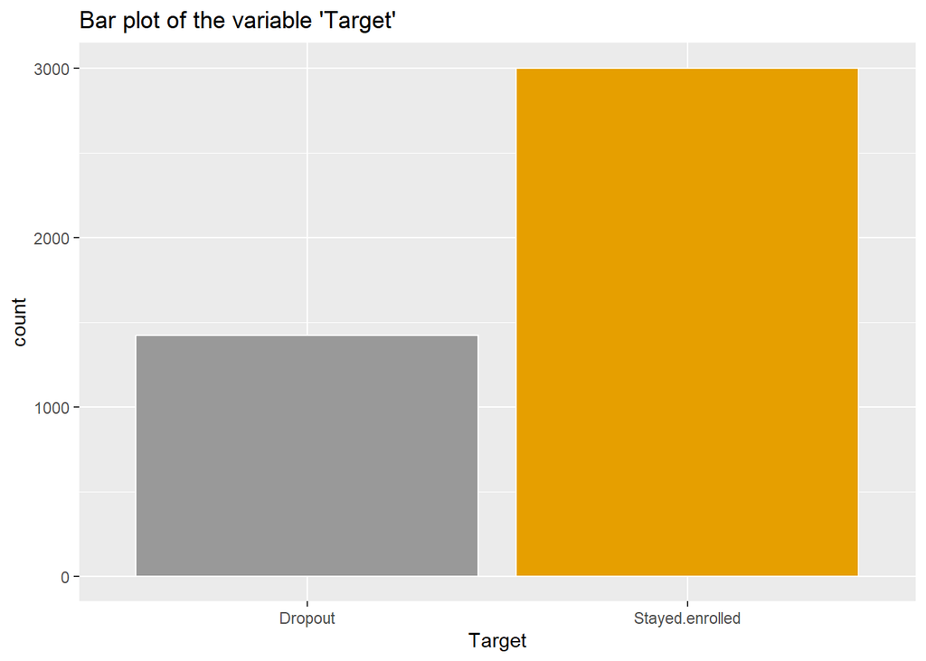

```r
ggplot( data = dropout ) +
    geom_bar( aes( x = Target ), binwidth = 1, color="white", fill = c( "#999999", "#E69F00" ) )  +
    labs( title = "Bar plot of the variable 'Target'" )
```

Summary for the target variable `Target`:

```r
summary( dropout $ Target )
```

```
##         Dropout Stayed.enrolled
##            1421            3003
```

Around 32% of all students never finished their studies. Compared to other European countries’ dropout rate, Portugal looks alike Italy and Slovenia which also have dropout rate higher than 30% (Kehm et al., 2019).

## 4.2 Investigate variable *Marital status*

Relationship between variable `Target` and `Marital status`:

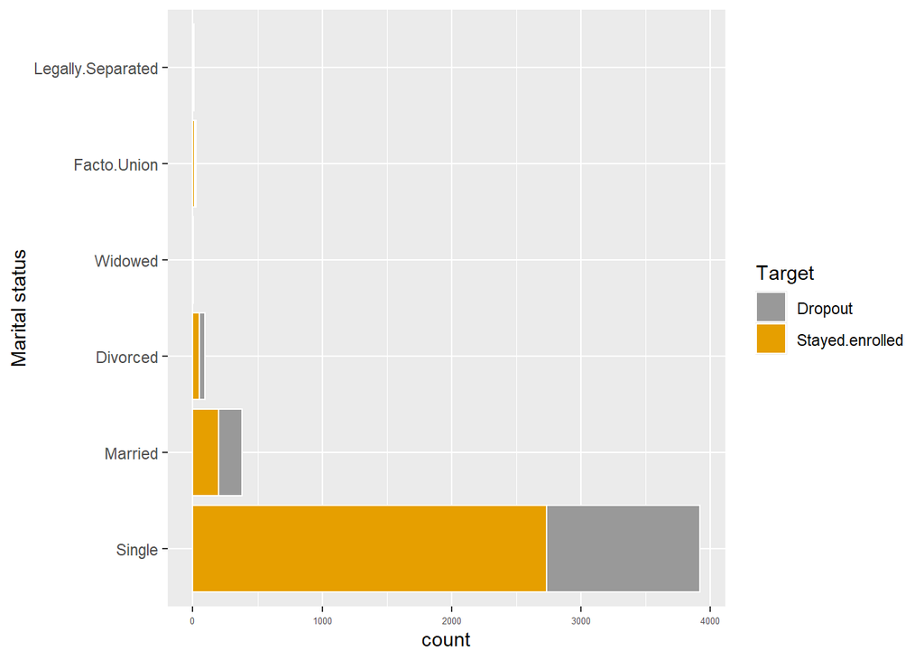

```r
ggplot( data = dropout ) +
  geom_bar( aes( x = `Marital status`, fill = `Target` ), position = "stack", binwidth = 1000, color="white" ) +
  theme(axis.text.x = element_text(size = 5)) +
  scale_fill_manual( values = c( "#999999", "#E69F00" ) ) +
  coord_flip()
```

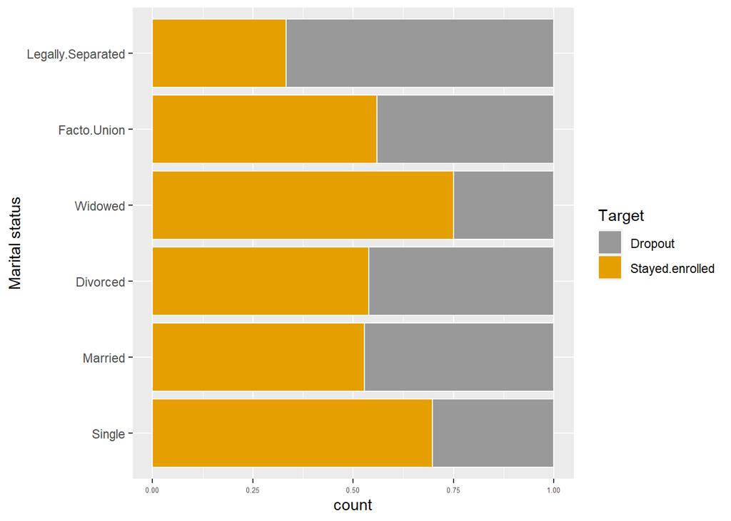

```r
ggplot( data = dropout ) +
  geom_bar( aes( x = `Marital status`, fill = `Target` ), position = "fill", binwidth = 1000, color="white" ) +
  theme(axis.text.x = element_text(size = 5)) +
  scale_fill_manual( values = c( "#999999", "#E69F00" ) ) +
  coord_flip()
```

```r
table( dropout $ `Target`, dropout $ `Marital status`, dnn = c( "Target", "Marital status" ) )
```

```
##                  Marital status
## Target            Single Married Divorced Widowed Facto.Union Legally.Separated
##   Dropout           1184     179       42       1          11                 4
##   Stayed.enrolled   2735     200       49       3          14                 2
```

We can observe a clear inequality in the proportion of students within the categories. The leading category is “Single” out of which approximately 70% of student stayed enrolled. It is understandable that most of the students enroll into he universities in the early stages of their lives and get married only after graduation. Because, there is still 20% difference in proportions between the most popular category and the second most popular category “Married”, we will conduct a Chi-Square test with significance level $\alpha=0.05$ to check whether this difference is statistically significant.

Our hypotheses are as follows:

$$\bigg\{
\begin{matrix}
H_0: \pi_{Legally.Separated, \ dropout} = \pi_{Facto.Union, \
dropout} = \pi_{Widowed, \ dropout} = \pi_{Divorced, \ dropout} =
\pi_{Married, \ dropout} = \pi_{Sindle, \ dropout} \\
H_a: At \ least \ one \ of \ the \ claims \ in \ H_0 \ is \ wrong.
\end{matrix}$$

```r
chisq.test( table(dropout $ `Target`, dropout $ `Marital status` ) )
```

```
##
##  Pearson's Chi-squared test
##
## data:  table(dropout$Target, dropout$`Marital status`)
## X-squared = 59.445, df = 5, p-value = 1.582e-11
```

Since the p-value (1.582e-11) is less than $\alpha=0.05$, thus we reject the $H_0$. Therefore, the difference in the marital status of the students, who stayed enrolled and dropped out is statistically significant. This means that the variable `Marital status` is useful to predict the target variable `Target`.

## 4.3 Investigate variable *Application order*

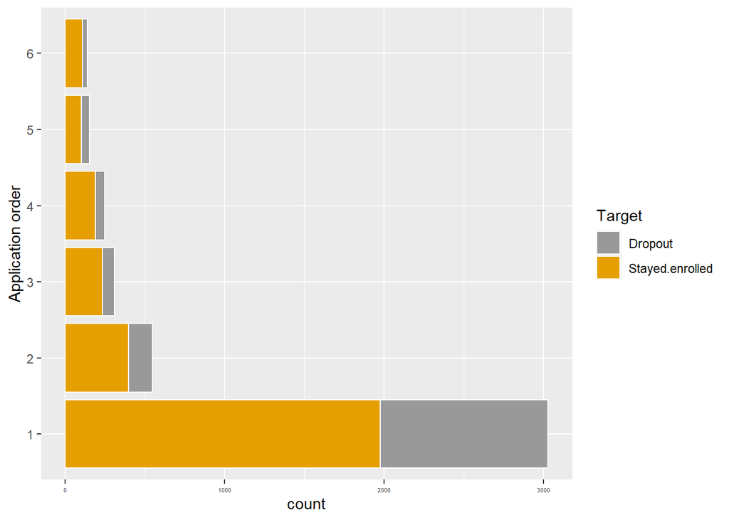

```r
dropout$`Application order` <- factor(dropout$`Application order`, levels = c("1", "2", "3", "4", "5", "6"))

ggplot( data = dropout ) +
  geom_bar( aes( x = `Application order`, fill = `Target` ),
  position =    "stack", binwidth = 1000, color="white" ) +
  theme(axis.text.x = element_text(size = 4)) +
  scale_fill_manual( values = c( "#999999", "#E69F00" ) ) + coord_flip()
```

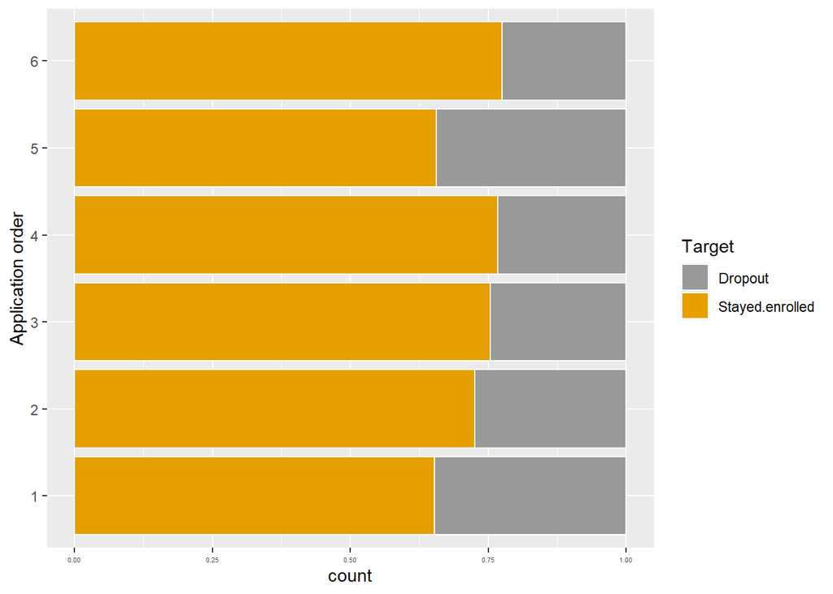

```r
ggplot( data = dropout ) +
  geom_bar( aes( x = `Application order`, fill = `Target` ),
  position =    "fill", binwidth = 1000, color="white" ) +
  theme(axis.text.x = element_text(size = 4)) +
  scale_fill_manual( values = c( "#999999", "#E69F00" ) )+
  coord_flip()
```

From the graph we can see an interesting finding. Highest dropout rates have students who were admitted to the university of their first choice. Lowest dropout rates have students who applied and got admitted to the university of their last choice. Maybe it is cause by the fact that people who chose national Portuguese universities as their last choice prioritize studies in other universities abroad. Therefore, such students are more educationally capable if they have an option to study abroad in the first place.

We still want to check if the variable `Application order` is a good predictor for `Target`. To test our results we need to implement a Chi-square test with significance level $\alpha=0.05$.

Our hypotheses are as follows:

$$\bigg\{
\begin{matrix}
H_0: \pi_{1,dropout} = \pi_{2,dropout} = \pi_{3,dropout} =
\pi_{4,dropout} = \pi_{5,dropout} = \pi_{6,dropout}, \\
H_a: At \ least \ one \ of \ the \ claims \ in \ H_0 \ is \ wrong.
\end{matrix}$$

```r
chisq.test( table(dropout $ `Target`, dropout $ `Application order` ) )
```

```
##
##  Pearson's Chi-squared test
##
## data:  table(dropout$Target, dropout$`Application order`)
## X-squared = 38.607, df = 5, p-value = 2.849e-07
```

Since the p-value (2.849e-07) is less than $\alpha=0.05$, thus we reject the $H_0$. Therefore, the difference in the application order of the student has a statistically significant impact on the choice of a student to dropout or to stay enrolled. This means that the variable `Application order` is useful to predict the target variable `Target`.

## 4.4 Investigate variable *Course*

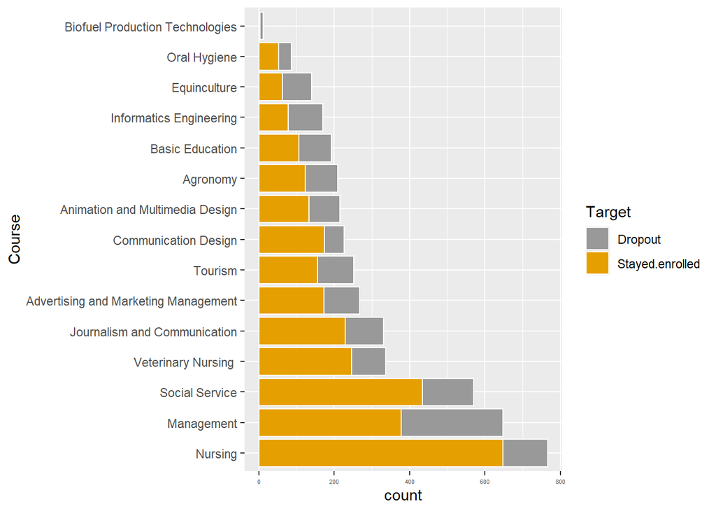

```r
ggplot( data = dropout ) +
  geom_bar( aes( x = fct_infreq(`Course`), fill = `Target` ),
  position =    "stack", binwidth = 1000, color="white" ) +
  theme(axis.text.x = element_text(size = 4)) +
  scale_fill_manual( values = c( "#999999", "#E69F00" ) ) +  xlab("Course") +
  coord_flip()
```

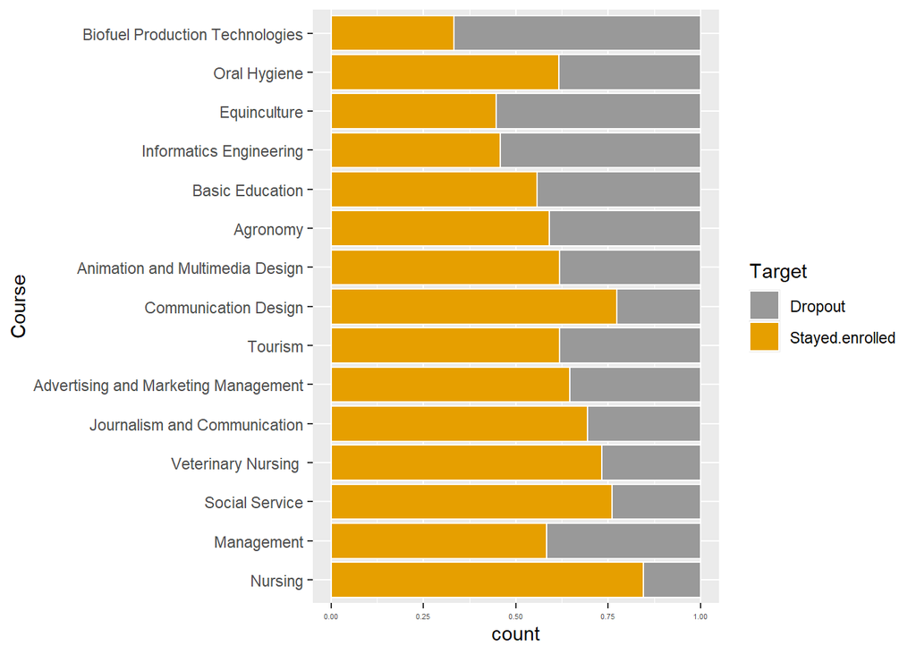

```r
ggplot( data = dropout ) +
  geom_bar( aes( x = fct_infreq(`Course`), fill = `Target` ),
  position = "fill", binwidth = 1000, color="white" ) +
  theme(axis.text.x = element_text(size = 4)) +
  scale_fill_manual( values = c( "#999999", "#E69F00" ) ) + xlab("Course") +
  coord_flip()
```

Looking at the distribution of dropout rates between the courses, we observe a fluctuation of the dropout rate with highest peaks at the “Biofuel Production Technologies” and “Equinculture”. The course that has the least dropouts is “Nursing”. Therefore, we will test our results with a Chi-square test with significance level $\alpha=0.05$.

Our hypotheses are as follows:

$$\bigg\{
\begin{matrix}
H_0: \pi_{1} = \pi_{2} = \pi_{3} = \pi_{4} = \pi_{5} = \pi_{6} =
\pi_{7} = \pi_{8} = \pi_{9} = \pi_{10} = \pi_{11} = \pi_{12} =
\pi_{13}= \pi_{14}= \pi_{15}\\
H_a: At \ least \ one \ of \ the \ claims \ in \ H_0 \ is \ wrong.
\end{matrix}$$

```r
chisq.test( table(dropout $ `Target`, dropout $ `Course` ) )
```

```
##
##  Pearson's Chi-squared test
##
## data:  table(dropout$Target, dropout$Course)
## X-squared = 267.69, df = 14, p-value < 2.2e-16
```

Since the p-value (2.2e-16) is less than $\alpha=0.05$, thus we reject the $H_0$. Therefore, the difference in the dropout rate between the courses, that students are enrolled in is statistically significant. This means that the variable `Course` is useful to predict the target variable `Target`.

## 4.5 Investigate variable *Evening attendance*

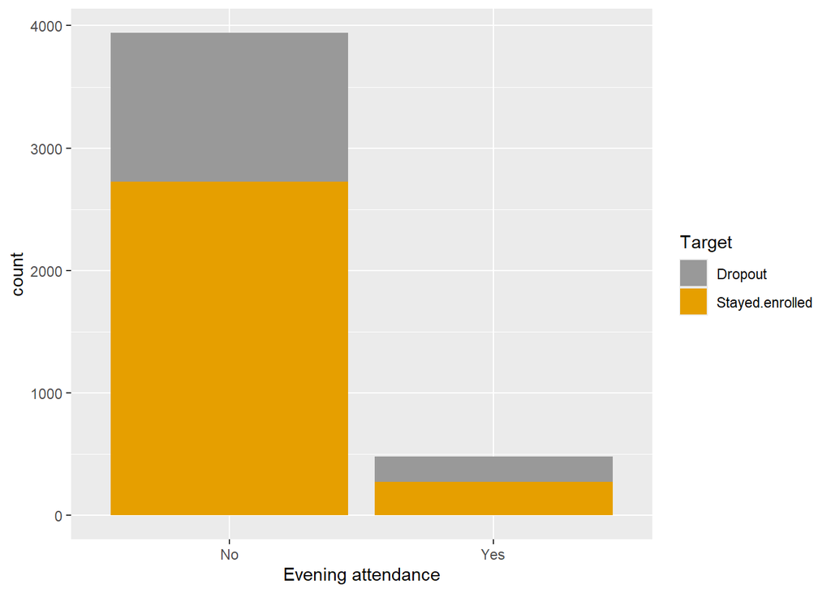

```r
ggplot(data = dropout) +
  geom_bar(aes(x = `Evening attendance`, fill = `Target`), position = "stack") +
  scale_fill_manual(values = c( "#999999", "#E69F00" ) )
```

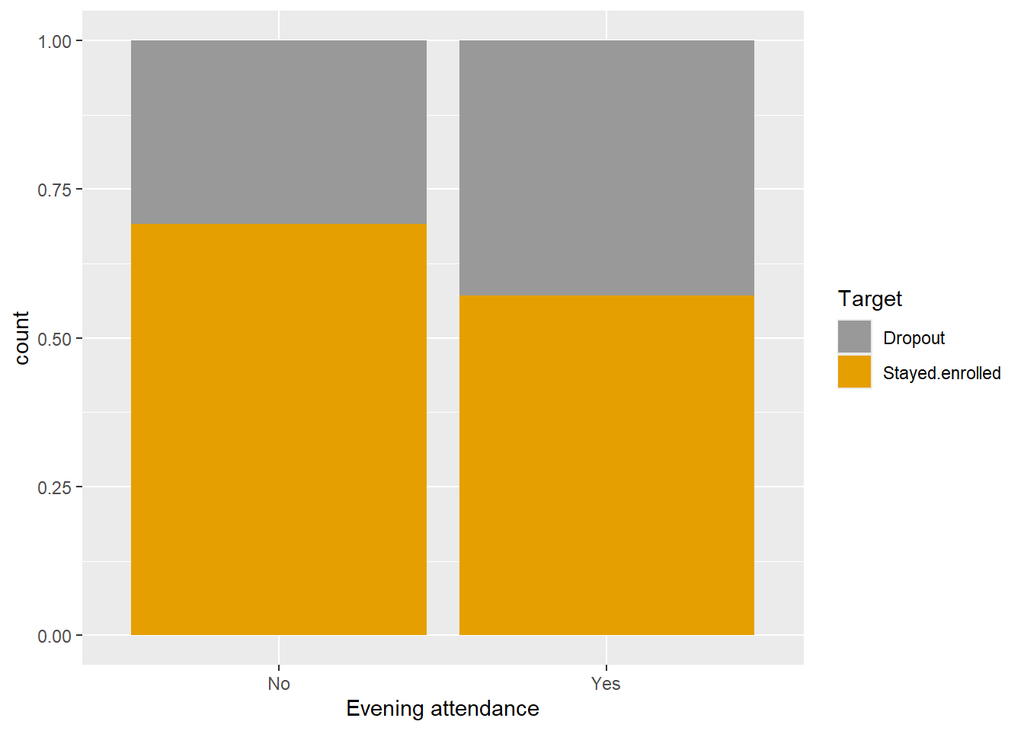

```r
ggplot(data = dropout) +
  geom_bar(aes(x = `Evening attendance`, fill = `Target`), position = "fill") +
  scale_fill_manual(values = c( "#999999", "#E69F00" ) )
```

We see that the dropout rate is around 10% higher for the students, who are attending evening education. This might be related to the fact, that students studying during daytime will focus more to their studies. We will conduct a Chi-square hypothesis test with significance level $\alpha=0.05$ to further prove this point.

Our hypotheses are as follows:

$$\bigg\{
\begin{matrix}
H_0: \pi_{evening \ attendance, \ dropout} = \pi_{(not) \ evening
\ attendance, \ dropout}, \\
H_a: \pi_{evening \ attendance,\ dropout} \neq \pi_{(not) \ evening
\ attendance, \ dropout}.
\end{matrix}$$

```r
chisq.test( table(dropout $ `Target`, dropout $ `Evening attendance` ) )
```

```
##
##  Pearson's Chi-squared test with Yates' continuity correction
##
## data:  table(dropout$Target, dropout$`Evening attendance`)
## X-squared = 28.118, df = 1, p-value = 1.142e-07
```

Since the p-value (1.142e-07) is less than $\alpha=0.05$, thus we reject the $H_0$. Therefore, the difference of the dropout rate in the proportions of students, who attend the evening studies and who do not is statistically significant. This means that the variable `Evening attendance` is useful to predict the target variable `Target`.

## 4.6 Investigate variable *Previous qualification*

Relationship between `Target` and `Previous qualification`

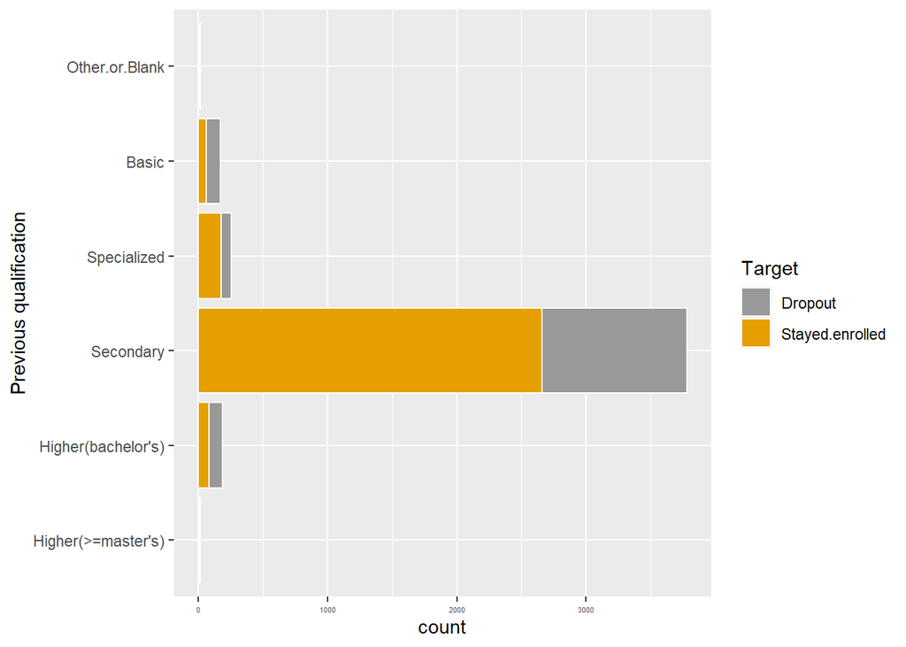

```r
dropout$`Previous qualification` <- factor(dropout$`Previous qualification`, levels = c("Higher(>=master's)", "Higher(bachelor's)", "Secondary", "Specialized", "Basic", "Other.or.Blank"))

ggplot( data = dropout ) +
  geom_bar( aes( x = `Previous qualification`, fill = `Target` ),
  position =    "stack", binwidth = 1000, color="white" ) +
  theme(axis.text.x = element_text(size = 4)) +
  scale_fill_manual( values = c( "#999999", "#E69F00" ) ) +
  coord_flip()
```

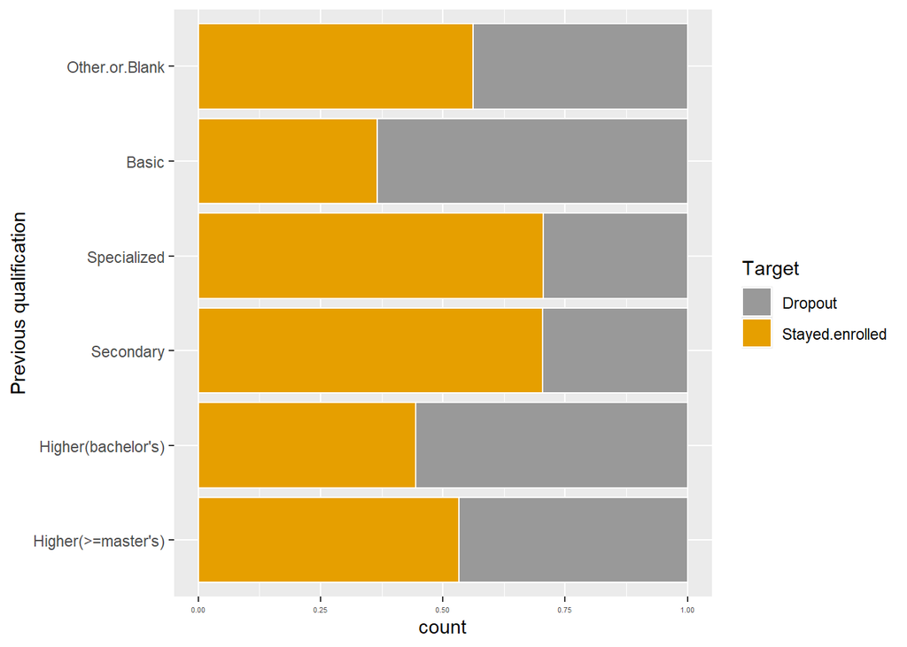

```r
ggplot( data = dropout ) +
  geom_bar( aes( x = `Previous qualification`, fill = `Target` ),
  position =    "fill", binwidth = 1000, color="white" ) +
  theme(axis.text.x = element_text(size = 4)) +
  scale_fill_manual( values = c( "#999999", "#E69F00" ) )+
  coord_flip()
```

```r
table( dropout $ `Target`, dropout $ `Previous qualification`, dnn = c( "Target", "Previous qualification" ) )
```

```
##                  Previous qualification
## Target            Higher(>=master's) Higher(bachelor's) Secondary Specialized
##   Dropout                          7                105      1118          75
##   Stayed.enrolled                  8                 84      2659         180
##                  Previous qualification
## Target            Basic Other.or.Blank
##   Dropout           109              7
##   Stayed.enrolled    63              9
```

We can observe a clear inequality in the proportion of students within the categories. However, from the second graph, it is clear that the categories “Secondary” and “Specialized” have the lowest dropout rate (around 70% of students stayed enrolled). That might be also related to the age of the students, since students with those previous qualifications are usually the youngest. Students with only “Basic” education probably experience the biggest dropout rate because of unpreparedness to the academically challenging environment. Therefore, we will conduct a Chi-Square test with significance level $\alpha=0.05$ to check whether this difference in categories is statistically significant.

Our hypotheses are as follows:

$$\bigg\{
\begin{matrix}
H_0: \pi_{Other.or.Blank, \ dropout} =
\pi_{Higher(>=master's), \ dropout} =
\pi_{Higher(bachelor's), \ dropout} = \pi_{Specialized, \ dropout} =
\pi_{Basic, \ dropout} = \pi_{Secondary, \ dropout} \\
H_a: At \ least \ one \ of \ the \ claims \ in \ H_0 \ is \ wrong.
\end{matrix}$$

```r
chisq.test( table(dropout $ `Target`, dropout $ `Previous qualification` ) )
```

```
##
##  Pearson's Chi-squared test
##
## data:  table(dropout$Target, dropout$`Previous qualification`)
## X-squared = 138.96, df = 5, p-value < 2.2e-16
```

Since the p-value (2.2e-16) is less than $\alpha=0.05$, thus we reject the $H_0$. Therefore, the difference in the previous qualification of the students, who stayed enrolled and dropped out is statistically significant. This means that the variable `Previous qualification` is useful to predict the target variable `Target`.

## 4.7 Investigate variables *Previous qualification (grade)* and *Admission grade*

Relationship between `Target` and `Previous qualification (grade)`/`Admission grade`:

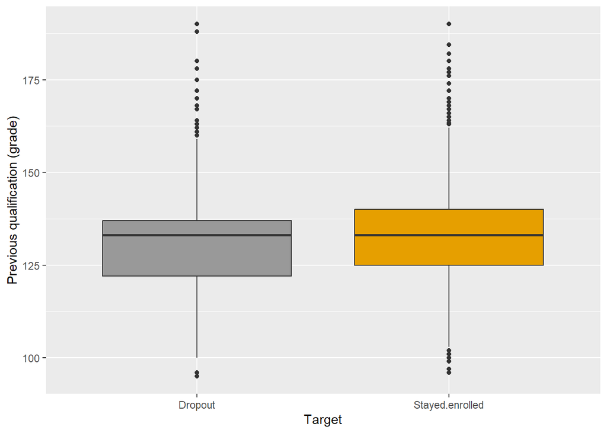

```r
ggplot (data = dropout, aes(x=`Target`, y=`Previous qualification (grade)`)) +
  geom_boxplot(fill= c( "#999999", "#E69F00" ) )
```

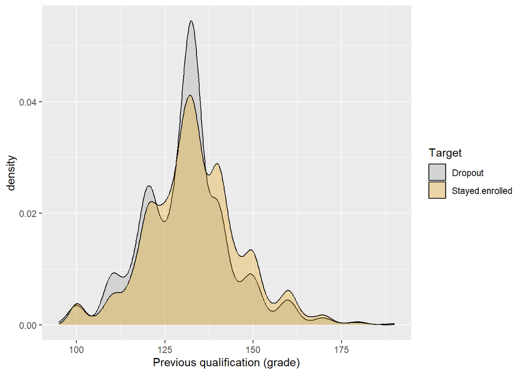

```r
ggplot( data = dropout ) +
  geom_density( aes( x = `Previous qualification (grade)`, fill = `Target`), alpha = 0.3 ) + scale_fill_manual(values = c( "#999999", "#E69F00" ) )
```

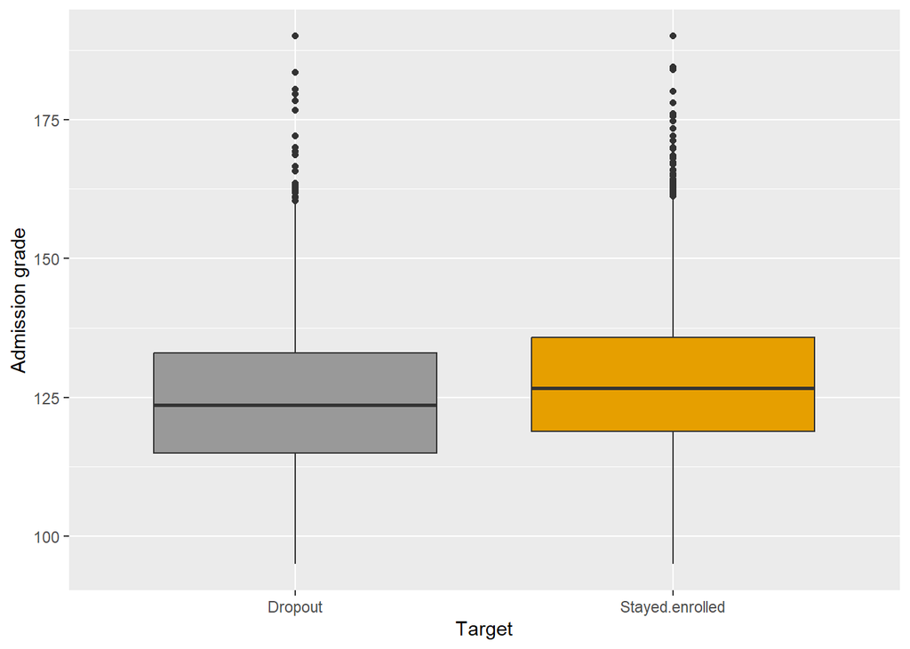

```r
ggplot (data = dropout, aes(x=`Target`, y=`Admission grade`)) +
  geom_boxplot(fill= c( "#999999", "#E69F00" ) )
```

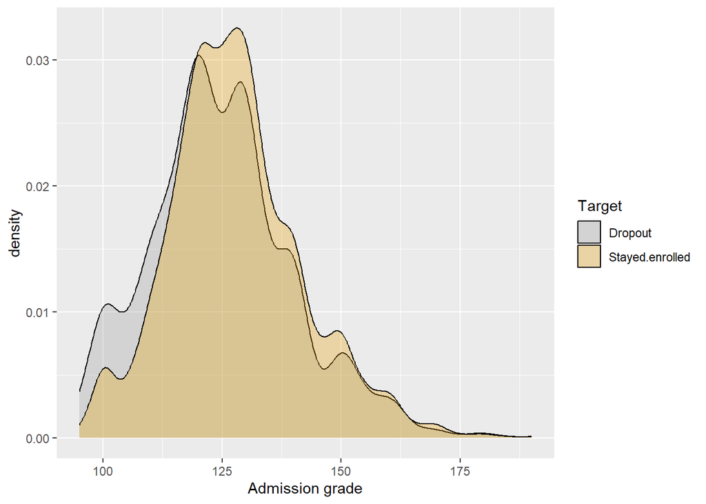

```r
ggplot( data = dropout ) +
  geom_density( aes( x = `Admission grade`, fill = `Target`), alpha = 0.3 ) + scale_fill_manual(values = c( "#999999", "#E69F00" ) )
```

Above density plots show slight fluctuations among previous/entrance grades of students who dropped out or who stayed enrolled. The nature of both variables `Previous qualification (grade)` and `Admission grade` is quite similar to each other so we want to test their correlation.

Our hypotheses are as follows:

$$\bigg\{
\begin{matrix}
H_0: \rho \leq 0, \\
H_a: \rho > 0.
\end{matrix}$$

```r
cor.test( x = dropout $ `Admission grade`,
          y = dropout $ `Previous qualification (grade)`,
          alternative = "greater",
          conf.level = 0.975 )
```

```
##
##  Pearson's product-moment correlation
##
## data:  dropout$`Admission grade` and dropout$`Previous qualification (grade)`
## t = 47.401, df = 4422, p-value < 2.2e-16
## alternative hypothesis: true correlation is greater than 0
## 97.5 percent confidence interval:
##  0.5605639 1.0000000
## sample estimates:
##       cor
## 0.5804442
```

We reject the $H_0$, since the p-value is less than 2.2e-16 which means it is too small, close to zero. It means with a 97.5% confidence the variables `Previous qualification (grade)` and `Admission grade` have a positive relationship which means the higher grade that student had during previous studies the higher grade he has for the admission. However, the correlation is not too high to consider eliminating one of the factors.

## 4.8 Investigate variables *Mother’s qualification, Mother’s occupation, Father’s qualification, Father’s occupation*

Relationship between `Target` and `Mother's qualification`, `Mother's occupation`, `Father's qualification`, `Father's occupation`

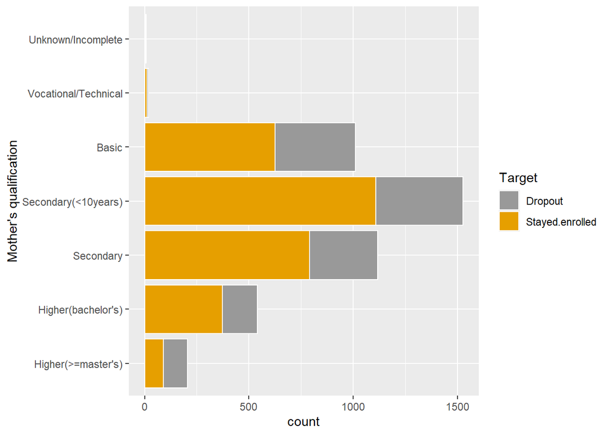

```r
dropout$`Mother's qualification` <- factor(dropout$`Mother's qualification`, levels = c("Higher(>=master's)", "Higher(bachelor's)", "Secondary", "Secondary(<10years)", "Basic", "Vocational/Technical", "Unknown/Incomplete"))

ggplot(data = dropout) +
  geom_bar(aes(x = `Mother's qualification`, fill = `Target`), position = "stack", binwidth = 1000, color="white") +
  scale_fill_manual(values = c( "#999999", "#E69F00" ) ) +
  coord_flip()
```

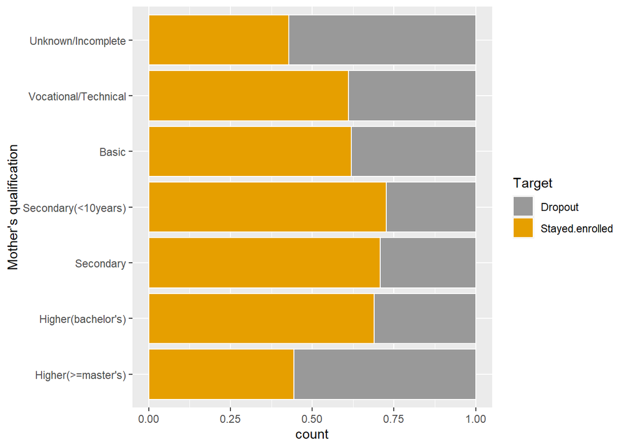

```r
ggplot(data = dropout) +
  geom_bar(aes(x = `Mother's qualification`, fill = `Target`), position = "fill", binwidth = 1000, color="white") +
  scale_fill_manual(values = c( "#999999", "#E69F00" ) ) +
  coord_flip()
```

```r
table( dropout $ `Target`, dropout $ `Mother's qualification`, dnn = c( "Target", "Mother's qualification" ) )
```

```
##                  Mother's qualification
## Target            Higher(>=master's) Higher(bachelor's) Secondary
##   Dropout                        114                168       326
##   Stayed.enrolled                 91                373       791
##                  Mother's qualification
## Target            Secondary(<10years) Basic Vocational/Technical
##   Dropout                         418   384                    7
##   Stayed.enrolled                1108   626                   11
##                  Mother's qualification
## Target            Unknown/Incomplete
##   Dropout                          4
##   Stayed.enrolled                  3
```

We can observe a clear inequality in the proportion of the categories. The above plot does not indicate a strong graphical evidence of the predictive importance of the variable `Mother's qualification`. The result are also a bit counter intuitive. The expected result would be that the dropout rate would be the lowest for the student’s, whose mother has a higher education. Because of this, we will test our results with a Chi-square test with significance level $\alpha=0.05$.

Our hypotheses are as follows:

$$\bigg\{
\begin{matrix}
H_0: \pi_{Unknown/Incomplete, \ dropout} =
\pi_{Vocational/Technical, \ dropout} = \pi_{Higher(>=master's),
\ dropout} = \pi_{Higher(bachelor's), \ dropout} = \pi_{Basic, \
dropout} = \pi_{Secondary, \ dropout} = \pi_{Secondary(<10years), \
dropout} \\
H_a: At \ least \ one \ of \ the \ claims \ in \ H_0 \ is \ wrong.
\end{matrix}$$

```r
chisq.test( table(dropout $ `Target`, dropout $ `Mother's qualification` ) )
```

```
##
##  Pearson's Chi-squared test
##
## data:  table(dropout$Target, dropout$`Mother's qualification`)
## X-squared = 90.732, df = 6, p-value < 2.2e-16
```

Since the p-value (2.2e-16) is less than $\alpha=0.05$, thus we reject the $H_0$. Therefore, the difference in the qualification of the student’s mother has a statistically significant impact on the choice of a student to dropout or to stay enrolled. This means that the variable `Mother's qualification` is useful to predict the target variable `Target`.

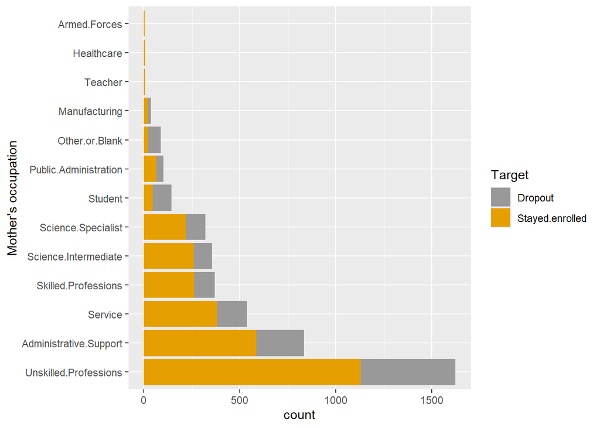

```r
ggplot(data = dropout) +
  geom_bar(aes(x = fct_infreq(`Mother's occupation`), fill = `Target`), position = "stack") +
  scale_fill_manual(values = c( "#999999", "#E69F00" ) ) + xlab("Mother's occupation") +
  coord_flip()
```

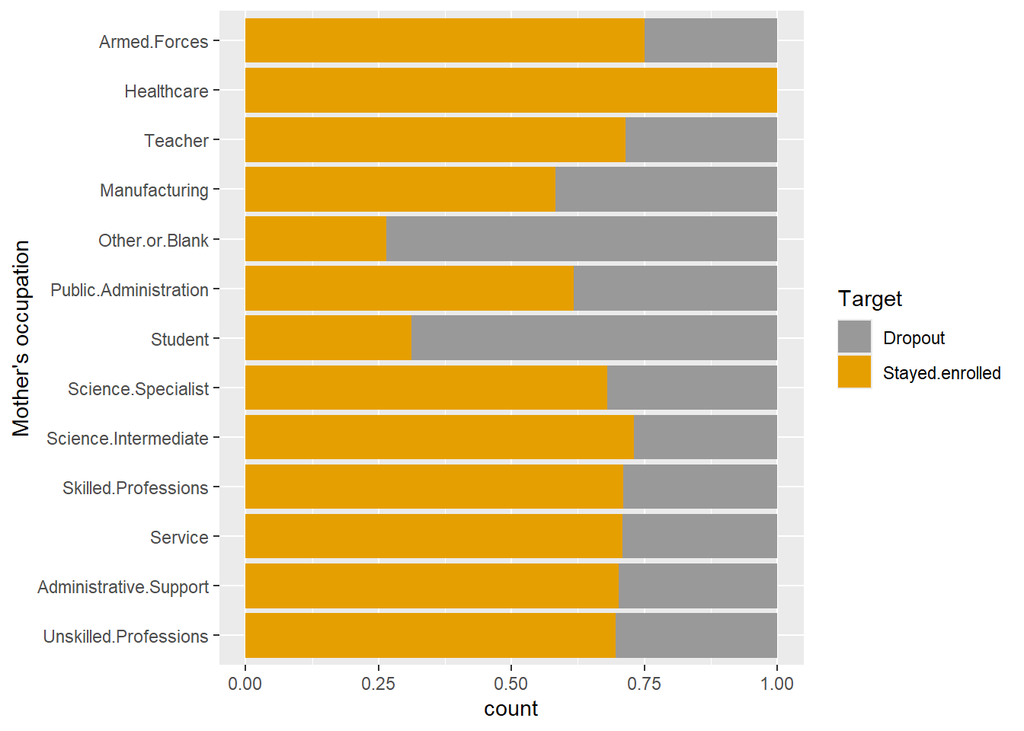

```r
ggplot(data = dropout) +
  geom_bar(aes(x = fct_infreq(`Mother's occupation`), fill = `Target`), position = "fill") +
  scale_fill_manual(values = c( "#999999", "#E69F00" ) ) +   xlab("Mother's occupation") +
  coord_flip()
```

```r
table( dropout $ `Target`, dropout $ `Mother's occupation`, dnn = c( "Target", "Mother's occupation" ) )
```

```
##                  Mother's occupation
## Target            Service Science.Intermediate Unskilled.Professions
##   Dropout             156                   96                   492
##   Stayed.enrolled     381                  260                  1131
##                  Mother's occupation
## Target            Skilled.Professions Administrative.Support
##   Dropout                         107                    248
##   Stayed.enrolled                 263                    586
##                  Mother's occupation
## Target            Public.Administration Science.Specialist Student
##   Dropout                            39                102      99
##   Stayed.enrolled                    63                217      45
##                  Mother's occupation
## Target            Other.or.Blank Manufacturing Healthcare Armed.Forces Teacher
##   Dropout                     64            15          0            1       2
##   Stayed.enrolled             23            21          5            3       5
```

We can observe a clear inequality in the proportion of the categories.The above plot does not indicate a strong graphical evidence of the predictive importance of the variable `Mother's occupation`. However, we observe that the dropout rate is the highest for the categories “Student” and “Other.or.Blank”, which is very intuitive. The student might have wanted to have the financial stability, that their parent couldn’t provide, so they went to the the job market without graduating. Because of this, we will test our results with a Chi-square test with significance level $\alpha=0.05$

Our hypotheses are as follows:

$$\bigg\{
\begin{matrix}
H_0: \pi_{1} = \pi_{2} = \pi_{3} = \pi_{4} = \pi_{5} = \pi_{6} =
\pi_{7} = \pi_{8} = \pi_{9} = \pi_{10} = \pi_{11} = \pi_{12} =
\pi_{13}\\
H_a: At \ least \ one \ of \ the \ claims \ in \ H_0 \ is \ wrong.
\end{matrix}$$

```r
chisq.test( table(dropout $ `Target`, dropout $ `Mother's occupation` ) )
```

```
##
##  Pearson's Chi-squared test
##
## data:  table(dropout$Target, dropout$`Mother's occupation`)
## X-squared = 175.91, df = 12, p-value < 2.2e-16
```

Since the p-value (2.2e-16) is less than $\alpha=0.05$, thus we reject the $H_0$. Therefore, the difference in the occupation of the student’s mother has a statistically significant impact on the choice of a student to dropout or to stay enrolled. This means that the variable `Mother's occupation` is useful to predict the target variable `Target`.

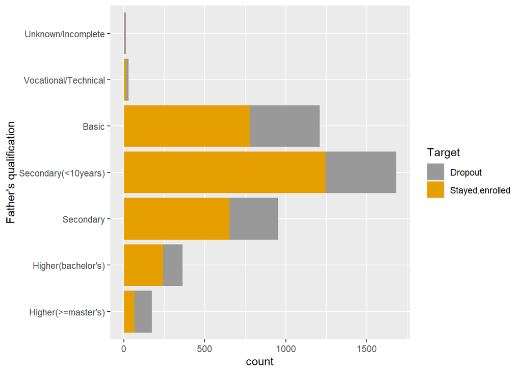

```r
dropout$`Father's qualification` <- factor(dropout$`Father's qualification`, levels = c("Higher(>=master's)", "Higher(bachelor's)", "Secondary", "Secondary(<10years)", "Basic", "Vocational/Technical", "Unknown/Incomplete"))

ggplot(data = dropout) +
  geom_bar(aes(x = `Father's qualification`, fill = `Target`), position = "stack") +
  scale_fill_manual(values = c( "#999999", "#E69F00" ) ) +
  coord_flip()
```

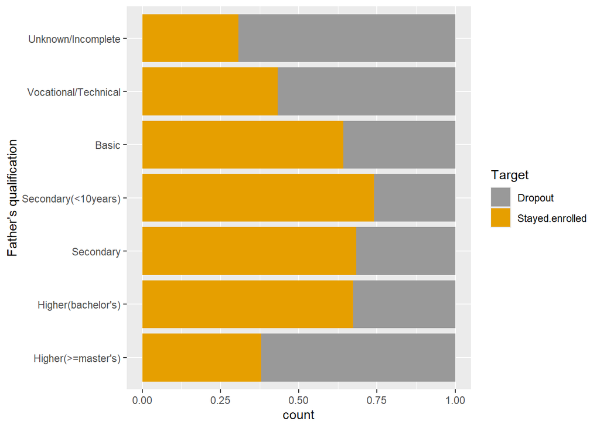

```r
ggplot(data = dropout) +
  geom_bar(aes(x = `Father's qualification`, fill = `Target`), position = "fill") +
  scale_fill_manual(values = c( "#999999", "#E69F00" ) ) +
  coord_flip()
```

We can observe a clear inequality in the proportion of the categories.The above plot does not indicate a strong graphical evidence of the predictive importance of the variable `Father's qualification`. The results are counter intuitive as, for instance, the dropout rate for the students whose father has less than 10 years of secondary education is a lot less than for the students, whose father has a master’s degree or higher . Because of this, we will test our results with a Chi-square test with significance level $\alpha=0.05$